# Bratwurst

Daniel Huebschmann & Sebastian Steinhauser

20.07.2016, major update 09.10.2017

# Contents

`Bratwurst` is a software package providing functions for preprocessing, wrappers for non-negative matrix factorization and postprocessing in `R`. This repo hosts the code of the Bratwurst software package.  
A detailed description of the software and an application to cells of the human hematopoietic system are available as a preprint: https://doi.org/10.1101/199547.  
Intermediate results for the analysis on hematopoietic cells are available on zenodo: https://doi.org/10.5281/zenodo.800049.  
In this README document, we present major parts of the vignette of the package. First some packages have to be loaded.

```r
library(knitr)
library(ComplexHeatmap)
```

# 1 Introduction

In 2015, Mejia-Roa et al. introduced an implementation of an NMF-solver in CUDA, which lead to significant reduction of computation times by making use of massive parallelisation on GPUs. Other implementations of NMF-solvers on GPUs exist.

It is the pupose of the package `Bratwurst` described here to provide wrapper functions in R to these NMF-solvers in CUDA. Massive parallelisation not only leads to faster algorithms, but also makes the benefits of NMF accessible to much bigger matrices. Furthermore, functions for preprocessing, estimation of the optimal factorization rank and post-hoc feature selection are provided.

# 2 The Bratwurst package

The main feature of the package `Bratwurst` is an S4 object called `nmf.exp`. It is derived from `SummarizedExperiment`, has containers for a data matrix, column annotation data and row annotation data and inherits `SummarizedExperiment`’s accessor functions `colData` and `rowData`. The matrix to be stored in this data structure is the matrix V as described above, corresponding to the input matrix for the NMF-solver. `nmf.exp` furthermore has containers for the matrices W and H which are results of the decomposition. As NMF algorithms have to be run iteratively, an instance of the class `nmf.exp` can store large lists of matrices, corresponding to the results of different iteration steps. Accessor functions to all different containers are provided.

A crucial step in data analysis with NMF is the determination of the optimal factorization rank, i.e. the number of columns of the matrix W or equivalently the number of rows of the matrix H. No consensus method for an automatic evaluation of the optimal factorization rank has been found to date. Instead, the decomposition is usually performed iteratively over a range of possible factorization ranks and different quality measures are computed for every tested factorization ranks. Many quality measures have been proposed:

- The `Frobenius reconstruction error`, i.e. the Frobenius norm of the residuals of the decomposition: ||W x H - V||
- Criteria to assess the stability of the decomposition:
- The `cophenetic correlation coefficient`
- An `Amari type distance`
- `Silhouette values` over clusters of patterns extracted iteratively at the same factorization rank

# 3 Example: leukemia data

In this README, as in the vignette for the package, we use a dataset containing Affymetrix Hgu6800 microarray expression data of B-ALL, T-ALL and AML samples. This dataset had also been used by Brunet et al. (PNAS, 2004) and Gaujoux et al. (BMC Bioinformatics, 2010). In Brunet et al., this dataset is called the **Golub** dataset. Preparations: load the necessary software packages:

```r
library(Bratwurst)
library(NMF)
```

Load the example data (the **Golub** dataset is stored in the R package `Bratwurst`)

```r
data(leukemia)
samples <- "leukemia"
```

This data was initially generated by the following commands:

```r
data.path  <- file.path(getwd(), "data")
matrix.file <- list.files(data.path, "*data.txt", full.names = T)
rowAnno.file <- list.files(data.path, "micro.*anno.*txt", full.names = T)
rowAnno.bed <- list.files(data.path, ".bed", full.names = T)
colAnno.file <- list.files(data.path, "sample.*anno.*txt", full.names = T)
# Read files to summarizedExperiment
leukemia.nmf.exp <- nmfExperimentFromFile(matrix.file = matrix.file,
                                          rowAnno.file = rowAnno.file,
                                          colData.file = colAnno.file)
save(leukemia.nmf.exp, file = file.path(data.path, "leukemia.rda"))
```

Now we are ready to start an NMF analysis.

## 3.1 NMF analysis

### 3.1.1 Call wrapper function

```r
k.max <- 4
outer.iter <- 10
inner.iter <- 10^4

leukemia.nmf.exp<- runNmfGpuPyCuda(nmf.exp = leukemia.nmf.exp,
                                   k.max = k.max,
                                   outer.iter = outer.iter,
                                   inner.iter = inner.iter,
                                   tmp.path = "/tmp/tmp_leukemia",
                                   cpu = TRUE)
```

```
## [1] "2017-10-09 14:37:55 CEST"
## Factorization rank:  2
## [1] "2017-10-09 14:38:11 CEST"
## Factorization rank:  3
## [1] "2017-10-09 14:38:30 CEST"
## Factorization rank:  4
```

Depending on the choice of parameters (dimensions of the input matrix, number of iterations), this step may take some time. Note that the algorithm updates the user about the progress in the iterations.

Several getter functions are available to access the data in the generated `nmf.exp` object:

### 3.1.2 `HMatrixList`

Returns a list of matrices `H` for a specific factorization rank `k`. There are as many entries in this list as there were iterations in the outer iteration. Of course the number of rows of the matrix `H` corresponds to the chosen factorization rank.

```r
tmp.object <- HMatrixList(leukemia.nmf.exp, k = 2)
class(tmp.object)
```

```
## [1] "list"
```

```r
length(tmp.object)
```

```
## [1] 10
```

```r
class(tmp.object[[1]])
```

```
## [1] "matrix"
```

```r
dim(tmp.object[[1]])
```

```
## [1]  2 38
```

If no value for `k` is supplied, the function returns a list of lists, one for every iterated factorization rank.

```r
tmp.object <- HMatrixList(leukemia.nmf.exp)
class(tmp.object)
```

```
## [1] "list"
```

```r
length(tmp.object)
```

```
## [1] 3
```

```r
class(tmp.object[[1]])
```

```
## [1] "list"
```

```r
length(tmp.object[[1]])
```

```
## [1] 10
```

### 3.1.3 `HMatrix`

Returns the matrix `H` for the optimal decomposition (i.e. the one with the minimal residual) for a specific factorization rank `k`. As in the previous paragraph, the number of rows of the matrix `H` corresponds to the chosen factorization rank.

```r
tmp.object <- HMatrix(leukemia.nmf.exp, k = 2)
class(tmp.object)
```

```
## [1] "matrix"
```

```r
dim(tmp.object)
```

```
## [1]  2 38
```

If no value for `k` is supplied, the function returns a list of optimal matrices, one for every iterated factorization rank.

```r
H.list <- HMatrix(leukemia.nmf.exp)
class(H.list)
```

```
## [1] "list"
```

```r
length(H.list)
```

```
## [1] 3
```

### 3.1.4 `WMatrixList`

Returns a list of matrices `W` for a specific factorization rank `k`. There are as many entries in this list as there were iterations in the outer iteration. Of course the number of columns of the matrix `W` corresponds to the chosen factorization rank.

```r
tmp.object <- WMatrixList(leukemia.nmf.exp, k = 2)
class(tmp.object)
```

```
## [1] "list"
```

```r
length(tmp.object)
```

```
## [1] 10
```

```r
class(tmp.object[[1]])
```

```
## [1] "matrix"
```

```r
dim(tmp.object[[1]])
```

```
## [1] 4951    2
```

If no value for `k` is supplied, the function returns a list of lists, one for every iterated factorization rank.

### 3.1.5 `WMatrix`

Returns the matrix `W` for the optimal decomposition (i.e. the one with the minimal residual) for a specific factorization rank `k`. As in the previous paragraph, the number of columns of the matrix `W` corresponds to the chosen factorization rank.

```r
tmp.object <- WMatrix(leukemia.nmf.exp, k = 2)
class(tmp.object)
```

```
## [1] "matrix"
```

```r
dim(tmp.object)
```

```
## [1] 4951    2
```

If no value for `k` is supplied, the function returns a list of optimal matrices, one for every iterated factorization rank.

```r
W.list <- WMatrix(leukemia.nmf.exp)
class(W.list)
```

```
## [1] "list"
```

```r
length(W.list)
```

```
## [1] 3
```

### 3.1.6 `FrobError`

Returns a data frame with as many columns as there are iterated factorization ranks and as many rows as there are iterations per factorization rank.

```r
FrobError(leukemia.nmf.exp)
```

```
## DataFrame with 10 rows and 3 columns
##            2         3         4
##    <numeric> <numeric> <numeric>
## 1  0.5583464 0.5139642 0.4641748
## 2  0.5583473 0.5139693 0.4644978
## 3  0.5583461 0.5139688 0.4646465
## 4  0.5583477 0.5139639 0.4644630
## 5  0.5583457 0.5139707 0.4645478
## 6  0.5583460 0.5139682 0.4644090
## 7  0.5583472 0.5139721 0.4644547
## 8  0.5583457 0.5139675 0.4646729
## 9  0.5583472 0.5139689 0.4645166
## 10 0.5583456 0.5139694 0.4646634
```

## 3.2 Determine the optimal factorization rank

In NMF, Several methods have been described to assess the optimal factorization rank. The Bratwurst packages implements some of them. They are computed by applying custom functions which subsequently update the data structure of type `nmf.exp`.

### 3.2.1 Get Frobenius error.

The most important information about the many iterated decompositions is the norm of the residual. In NMF this is often called the Frobenius error, as the Frobenius norm may be used.

```r
leukemia.nmf.exp <- computeFrobErrorStats(leukemia.nmf.exp)
```

### 3.2.2 Evaluate silhouette values

In 2013, Alexandrov et al. published an NMF analysis on mutational signatures. They used an approach which a modified silhouette criterion is used to estimate the stability across iteration steps for one fixed factorization rank `k`.

```r
leukemia.nmf.exp <- computeSilhoutteWidth(leukemia.nmf.exp)
```

### 3.2.3 Cophenetic correlation coefficient plot

```r
leukemia.nmf.exp <- computeCopheneticCoeff(leukemia.nmf.exp)
```

### 3.2.4 Compute amari type distance

```r
leukemia.nmf.exp <- computeAmariDistances(leukemia.nmf.exp)
```

After having executed all these functions, the values of the computed measures can be accessed with `OptKStats`:

```r
OptKStats(leukemia.nmf.exp)
```

```
## DataFrame with 3 rows and 9 columns
##           k       min      mean           sd           cv sumSilWidth
##   <numeric> <numeric> <numeric>    <numeric>    <numeric>   <numeric>
## 2         2 0.5583456 0.5583465 7.751192e-07 1.388241e-06    20.00000
## 3         3 0.5139639 0.5139683 2.577000e-06 5.013928e-06    29.99996
## 4         4 0.4641748 0.4645046 1.482698e-04 3.191999e-04    39.99228
##   meanSilWidth copheneticCoeff meanAmariDist
##      <numeric>       <numeric>     <numeric>
## 2    0.9999999       0.9999999  2.709082e-08
## 3    0.9999988       0.9616090  3.969754e-07
## 4    0.9998071       0.9866591  8.592894e-05
```

These quality measures can be displayed together:

### 3.2.5 Generate plots to estimate optimal k

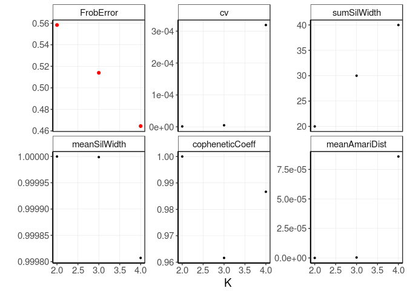

```r
gg.optK <- plotKStats(leukemia.nmf.exp)
gg.optK
```

### 3.2.6 Generate ranked error plot.

It may also be useful to inspect the Frobenius error after ranking. This may give an estimation of the convergence in the parameter space of initial conditions.

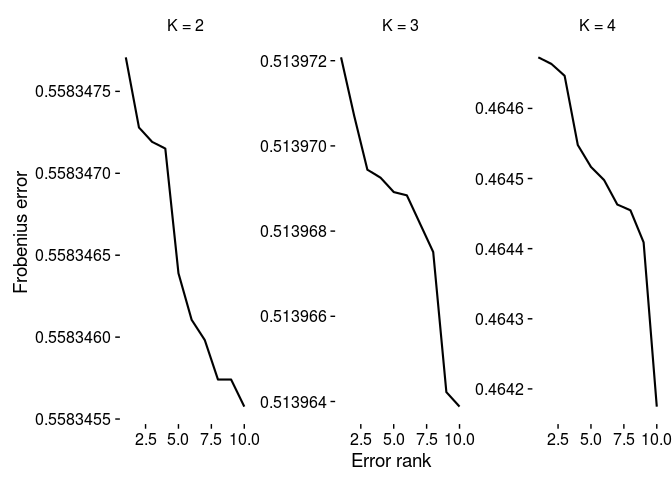

```r
gg.rankedFrobError <- plotRankedFrobErrors(leukemia.nmf.exp)
gg.rankedFrobError
```

## 3.3 Visualize the matrix H (exposures)

The matrices `H` may be visualized as heatmaps. We can define a meta information object and annotate meta data:

```r
entity.colVector <- c("red", "blue")
names(entity.colVector) <- c("ALL", "AML")
subtype.colVector <- c("orange", "darkgreen", "blue")
names(subtype.colVector) <- c("B-cell", "T-cell", "-")
anno_col <- list(V2 = entity.colVector,
                 V3 = subtype.colVector)
heat.anno <- HeatmapAnnotation(df = colData(leukemia.nmf.exp)[, c(2:3)],
                               col = anno_col)
```

And now display the matrices `H` with meta data annotation. Bratwurst provides a plotting function to display the matrices `H` with meta data annotation:

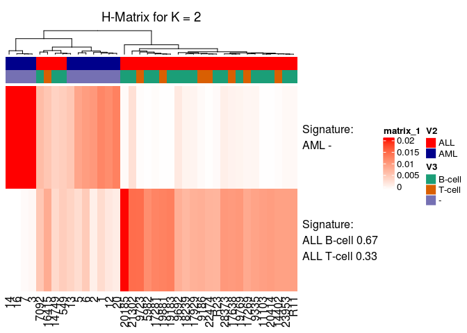

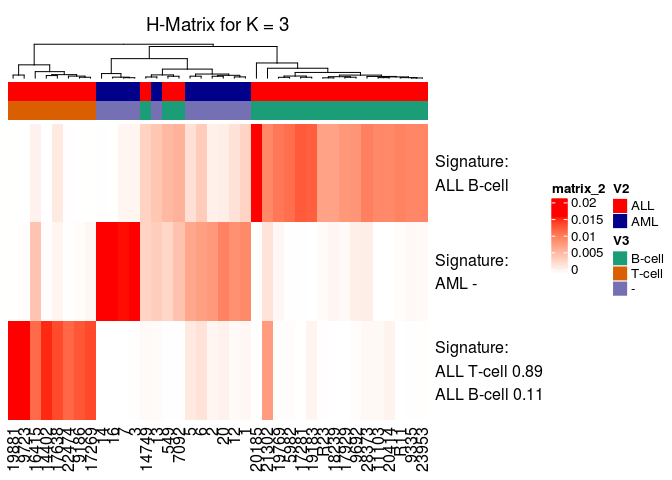

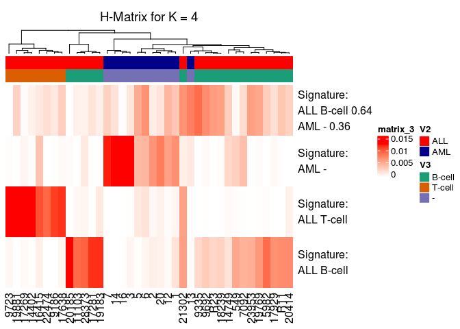

```r
# Plot Heatmaps for H over all k
lapply(seq(2, k.max), function(k) {
  plotHMatrix(leukemia.nmf.exp, k)
})
```

## 3.4 Feature selection

### 3.4.1 Row K-means to determine signature specific features

```r
### Find representative regions.
# Get W for best K
leukemia.nmf.exp <- setOptK(leukemia.nmf.exp, 4)
OptK(leukemia.nmf.exp)
```

```
## [1] 4
```

```r
signature.names <- getSignatureNames(leukemia.nmf.exp, OptK(leukemia.nmf.exp))
signature.names
```

```
## [1] "ALL B-cell 0.64\nAML - 0.36" "AML -"
## [3] "ALL T-cell"                  "ALL B-cell"
```

```r
FeatureStats(leukemia.nmf.exp)
```

```
## DataFrame with 0 rows and 0 columns
```

```r
leukemia.nmf.exp <- computeFeatureStats(leukemia.nmf.exp)
FeatureStats(leukemia.nmf.exp)
```

```
## DataFrame with 4951 rows and 7 columns
##          cluster deltaCenters  deltaMean explainedVar    oddsVar   coefVar
##      <character>    <numeric>  <numeric>    <numeric>  <numeric> <numeric>
## 1           1000    0.5598768  40404.983    0.9290739 0.07634068 0.9366928
## 2           1011    0.3803309   2573.797    0.9388679 0.06511258 0.3902262
## 3           0101   -0.4294660 -24040.664    0.9588564 0.04290901 0.5927406
## 4           1000    0.5226433   5657.101    0.9607982 0.04080124 0.8355173
## 5           1100    0.2919822   3304.288    0.7907449 0.26463040 0.4499437
## ...          ...          ...        ...          ...        ...       ...
## 4947        1000    0.3247738  1558.5093    0.9386278 0.06538501 0.4453941
## 4948        1011    0.3931513 22919.0305    0.8101850 0.23428596 0.4533714
## 4949        1000    0.4427220 11509.2834    0.8894812 0.12425081 0.6686290
## 4950        1001    0.2278627   929.7619    0.7930793 0.26090794 0.3449582
## 4951        1011    0.4895291 13897.9083    0.7588860 0.31772096 0.6473873
##        meanSil
##      <numeric>
## 1    0.5842238
## 2    0.6015913
## 3    0.7912017
## 4    0.6246600
## 5    0.4495862
## ...        ...
## 4947 0.5933313
## 4948 0.4366444
## 4949 0.5301540
## 4950 0.4561943
## 4951 0.3617552
```

```r
# You might want to add additional selection features
# such as entropy or absolute delta
# Entropy
leukemia.nmf.exp <- computeEntropy4OptK(leukemia.nmf.exp)
FeatureStats(leukemia.nmf.exp)
```

```
## DataFrame with 4951 rows and 8 columns
##          cluster deltaCenters  deltaMean explainedVar    oddsVar   coefVar
##      <character>    <numeric>  <numeric>    <numeric>  <numeric> <numeric>
## 1           1000    0.5598768  40404.983    0.9290739 0.07634068 0.9366928
## 2           1011    0.3803309   2573.797    0.9388679 0.06511258 0.3902262
## 3           0101   -0.4294660 -24040.664    0.9588564 0.04290901 0.5927406
## 4           1000    0.5226433   5657.101    0.9607982 0.04080124 0.8355173
## 5           1100    0.2919822   3304.288    0.7907449 0.26463040 0.4499437
## ...          ...          ...        ...          ...        ...       ...
## 4947        1000    0.3247738  1558.5093    0.9386278 0.06538501 0.4453941
## 4948        1011    0.3931513 22919.0305    0.8101850 0.23428596 0.4533714
## 4949        1000    0.4427220 11509.2834    0.8894812 0.12425081 0.6686290
## 4950        1001    0.2278627   929.7619    0.7930793 0.26090794 0.3449582
## 4951        1011    0.4895291 13897.9083    0.7588860 0.31772096 0.6473873
##        meanSil    entropy
##      <numeric>  <numeric>
## 1    0.5842238 0.41736287
## 2    0.6015913 0.09377805
## 3    0.7912017 0.19862689
## 4    0.6246600 0.32592530
## 5    0.4495862 0.10924133
## ...        ...        ...
## 4947 0.5933313 0.09745639
## 4948 0.4366444 0.12369820
## 4949 0.5301540 0.21847701
## 4950 0.4561943 0.06351516
## 4951 0.3617552 0.26069339
```

```r
leukemia.nmf.exp <- computeAbsDelta4OptK(leukemia.nmf.exp)
FeatureStats(leukemia.nmf.exp)
```

```
## DataFrame with 4951 rows and 12 columns
##          cluster deltaCenters  deltaMean explainedVar    oddsVar   coefVar
##      <character>    <numeric>  <numeric>    <numeric>  <numeric> <numeric>
## 1           1000    0.5598768  40404.983    0.9290739 0.07634068 0.9366928
## 2           1011    0.3803309   2573.797    0.9388679 0.06511258 0.3902262
## 3           0101   -0.4294660 -24040.664    0.9588564 0.04290901 0.5927406
## 4           1000    0.5226433   5657.101    0.9607982 0.04080124 0.8355173
## 5           1100    0.2919822   3304.288    0.7907449 0.26463040 0.4499437
## ...          ...          ...        ...          ...        ...       ...
## 4947        1000    0.3247738  1558.5093    0.9386278 0.06538501 0.4453941
## 4948        1011    0.3931513 22919.0305    0.8101850 0.23428596 0.4533714
## 4949        1000    0.4427220 11509.2834    0.8894812 0.12425081 0.6686290
## 4950        1001    0.2278627   929.7619    0.7930793 0.26090794 0.3449582
## 4951        1011    0.4895291 13897.9083    0.7588860 0.31772096 0.6473873
##        meanSil    entropy absDelta.V1 absDelta.V2 absDelta.V3 absDelta.V4
##      <numeric>  <numeric>   <numeric>   <numeric>   <numeric>   <numeric>
## 1    0.5842238 0.41736287   16700.196  -55929.744  -74379.973  -62019.591
## 2    0.6015913 0.09377805   -4424.995  -10895.600   -6643.628   -6175.400
## 3    0.7912017 0.19862689  -68083.015  -30868.132  -76178.055  -17230.281
## 4    0.6246600 0.32592530    1648.302   -8626.609  -10557.755   -9813.338
## 5    0.4495862 0.10924133   -4115.362   -8767.533  -14313.137  -11786.910
## ...        ...        ...         ...         ...         ...         ...
## 4947 0.5933313 0.09745639  -1224.0405   -4621.225   -4470.665   -3931.287
## 4948 0.4366444 0.12369820 -67440.3287  -93600.108  -39650.117  -36195.695
## 4949 0.5301540 0.21847701   -472.5316  -23193.018  -27132.367  -20147.910
## 4950 0.4561943 0.06351516  -3307.7331   -4171.742   -4835.147   -1980.109
## 4951 0.3617552 0.26069339  -7152.3087  -47534.210  -32293.208  -19769.663
```

### 3.4.2 Feature visualization

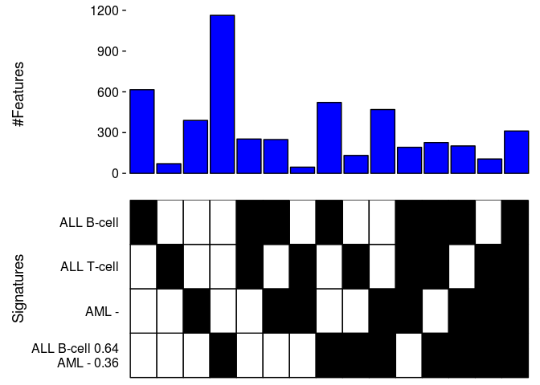

```r
# Plot all possible signature combinations
plotSignatureFeatures(leukemia.nmf.exp)
```

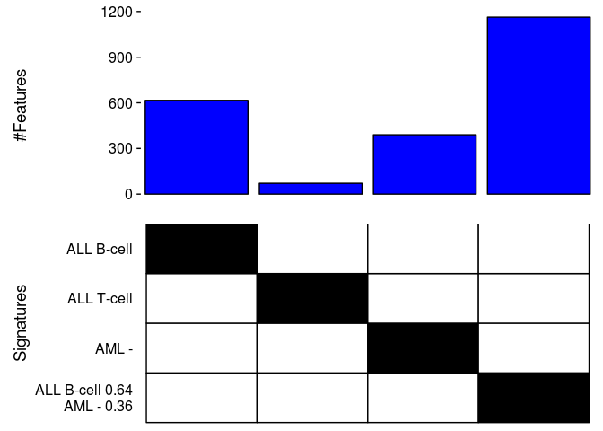

```r
# Plot only signature combinations
plotSignatureFeatures(leukemia.nmf.exp, sig.combs = F)
```

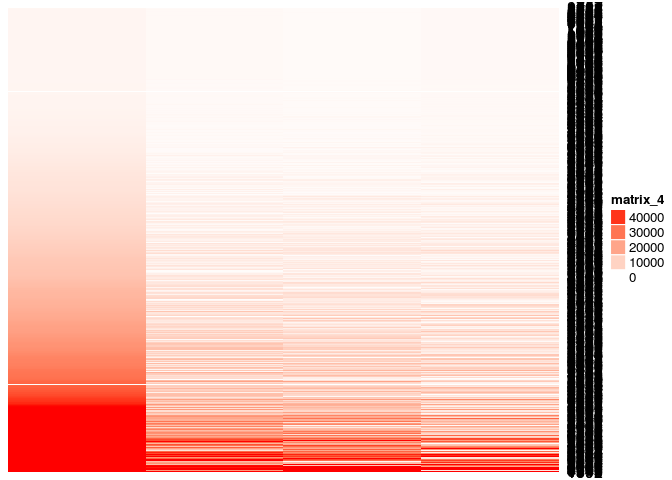

```r
# Try to display selected features on W matrix
sig.id <- "1000"
m <- WMatrix(leukemia.nmf.exp, k = OptK(leukemia.nmf.exp))[
  FeatureStats(leukemia.nmf.exp)[, 1] == sig.id, ]
m <- m[order(m[, 1]), ]
c <- getColorMap(m)
#m <- t(apply(m, 1, function(r) (r - mean(r))/sd(r)))

Heatmap(m, col = c, cluster_rows = F, cluster_columns = F)
```